# Amphibians

Jeanne Tarrant<sup>1</sup> , Joshua Weeber<sup>2</sup> , Domitilla C. Raimondo<sup>3</sup> , Maphale S. Monyeki<sup>3</sup> , Dewidine van Der Colff<sup>3</sup> , Shae-Lynn E. Hendricks<sup>3</sup>

1. Anura Africa/Amphibian Specialist Group

2. Endangered Wildlife Trust

3. South African National Biodiversity Institute

Published

December 5, 2025

[figure not shown]

Pickersgill’s reed frog (*Hyperolius pickersgilli*) is a species that has received extensive collaborative conservation focus over the last decade in South Africa. These efforts have resulted in its protection level improving from poorly protected in 2018 to moderately protected in 2025. (© Tyrone Ping)

22%  
of 135 species assessed are  
Threatened

73%  
of 133 assessed species are  
Well Protected

79%  
of threatened amphibians are  
Under-protected

## Key findings

[figure not shown]

Figure 1. Threatened amphibian richness across South Africa, mapped as the number of threatened species per 10 x 10 km grid cell.

## Threat status

**Figure**

[figure not shown]

Figure 2. Threat status of South African amphibian species assessed following the IUCN 3.1 Red List Categories and Criteria. A shows the proportion of all species in each category, while B is the proportion of endemic species per category. The total number of species that have been assessed is indicated within each circle.

**Data**

Table 1. Summary statistics for percentage threatened and endemic amphibians, and the number of species within each threat category.

| Taxon | Critically Endangered | Endangered | Vulnerable | Near Threatened | Data Deficient | Least Concern | Total |
| --- | --- | --- | --- | --- | --- | --- | --- |
| Overall amphibians | 4 | 18 | 7 | 12 | 2 | 92 | 135 |
| Endemic amphibians | 4 | 17 | 5 | 10 | 2 | 37 | 75 |

**NoteBox 1. New knowledge informs our understanding of extinction risk**

## Moonlight Mountain toadlet (*Capensibufo selenophos*)

Better data available for the latest assessment allowed the risk of extinction of three species previously categorised as Data Deficient to now be quantified. One, the Moonlight Mountain toadlet (*Capensibufo selenophos*) is now classified as Endangered, while the others were assessed as Near Threatened. These assessments are aligned with established findings that better knowledge of Data Deficient species often reveal that they are of conservation concern<sup>1</sup> and demonstrate the value of prioritising funding and resources towards dedicated surveys of poorly known species. The [Endangered Wildlife Trust](https://ewt.org/) secured funding for habitat surveys and engagement with landowners on habitat protection. Seven previously unknown subpopulations of *C. selenophos* were confirmed across the Akkedisberg , Kleinrivier and Soetmuisberg Mountains in the Western Cape.

[figure not shown]

Moonlight Mountain toadlet (*Capensibufo selenophos*). (© Keir Lynch)

Knowledge of threats were improved, and one property (approximately 700 ha) has been declared as a nature reserve through the [Biodiversity Stewardship](https://www.sanbi.org/biodiversity/science-into-policy-action/mainstreaming-biodiversity/biodiversity-and-land-use-project/biodiversity-stewardship/) process and is being actively managed for control of alien invasive plants. This new information resulted in a non-genuine change (change in status due change in taxonomy, better available data or improved understanding of the criteria, see Butchart et al. (2004)<sup>2</sup> for further information) from Data Deficient to Endangered based on an EOO of 478 km<sup>2</sup>, and improved understanding of threats including deterioration of habitat quality, and suspected declines.

## Boston rain frog (*Breviceps batrachophiliorum*)

An example of a newly described species being assessed at the time in 2025 is the Boston rain frog (*Breviceps batrachophiliorum*), which was recognised as distinct from *B. bagginsi* by Du Preez et al. 2025)<sup>3</sup> based on morphological, call and genetic analyses. The resulting split led to an assessment of Endangered for *B. batrachophiliorum* and Critically Endangered for *B. bagginsi*. This grassland-associated species is restricted to the Midlands area in south central KwaZulu-Natal province.

[figure not shown]

Boston rain frog (*Breviceps batrachophiliorum*). (© Louis Du Preez)

Records are confirmed from the Boston (type locality), Richmond, Karkloof and Bulwer areas. Currently, the species is understood to occur at three subpopulations across less than 3000 km<sup>2</sup>.

## Table Mountain ghost frog (*Heleophryne rosei*)

The Table Mountain ghost frog (*Heleophryne rosei*) provides an interesting example of how new information, and correct application of the IUCN Categories and Criteria can impact the perceived extinction risk of a species. *Heleophryne rosei* has been listed as Critically Endangered for over 20 years, during which the same four threats have been implicated in reducing stream quality and extent. Despite this, there were no detailed studies undertaken to link specific threats to aspects of the species’ ecology to understand presumed declines and inform conservation actions. As such, the species remained listed as Critically Endangered because of on-going declines in habitat quality, small EOO, and one threat defined location. This began to change in 2019 when a multi-stakeholder project was launched to obtain fine-scale data on the species, increasing our understanding of magnitude and source of threats. While this habitat

[figure not shown]

Table Mountain ghost frog (*Heleophryne rosei*). (© Joshua Weeber)

specialist is still extremely range-restricted and experiencing continued habitat loss, the project revealed that the location and source of known threats are diverse and the species is therefore considered to occur at 2-4 threat locations (different streams on Table Mountain), meaning it now qualifies for listing as Endangered. Data from this project are now being used to inform management frameworks for headwater mountain streams, emphasising the importance of fine-scale studies in amphibian conservation in South Africa, and supporting the view that priority research needs to inform conservation of amphibians<sup>4</sup>.

## Trends - the Red List Index

The trend in species status over time was measured using the globally recognised indicator, the IUCN Red List Index of species (RLI)<sup>2</sup>. The RLI is calculated based on genuine changes in Red List categories over time. The RLI value ranges from 0 to 1, and if the value is 1, all taxa are Least Concern, and if the value is 0, all taxa are extinct. The slope of the line shows the rate at which the taxonomic group is heading towards extinction. The Red List Index of amphibians was calculated for all amphibian taxa that have been reassessed (n = 135, Figure 3).

Thirty species have had a change in status since the latest assessment (2016). However, only two of these are genuine changes: *Breviceps macrops* – desert rain frog (NT to VU) and *Amietia hymenopus* - Phofung river frog (NT to VU). These species are spatially isolated; however, they share some pressures, as both *Breviceps macrops* and *Amietia hymenopus* are likely to be impacted by climate change. The former is restricted to the dry West Coast of South Africa and relies on limited precipitation in the form of fog; and the latter occurs in streams along the Drakensberg Escarpment and Lesotho, which may face increased drying and extreme weather events (Figure 4). Both species are also impacted by the expansion of mining activities, *B. macros* specifically on the West Coast, due to the future planned development of Green Hydrogen and *A. hymenopus* in the highlands of Lesotho into South Africa (Table 2).

The remaining species that have had a change in their status were considered to be non-genuine changes due to new information, taxonomic changes, application of criteria, (see Box 1 for examples). There has been no improvement in the status of amphibians during the assessment period. Important to note is that amphibians remain threatened by pressures that have not ceased and are increasing in most instances. Of particular concern are the impacts of invasive alien species, which affect 83% of threatened species, particularly in cases where the spread of invasive species is continuing or increasing. Impacts of this threat include drying out and replacement of habitat by alien invasive plants, diseases such as *chytridiomycosis*, and competition with problematic native species (Box 2).

**Figure**

[figure not shown]

Figure 3. The Red List Index (RLI) for amphibian species in South Africa. The slope of the line indicates the rate at which species within each taxonomic group are becoming more threatened over time, with steeper slopes indicating more rapid decline towards extinction. Aggregate refers to the national average RLI across all assessed taxonomic groups.

**Data**

Table 2. List of taxa that have had a genuine change in their status and the drivers. Asterisks indicate endemism levels: * endemic and ** near-endemic.

Taxon

Change of Status (2016 to 2025)

Direction of change

Reason for change

[*Amietia hymenopus*](https://www.inaturalist.org/observations?verifiable=true&taxon_id=476398&place_id=6986&preferred_place_id=6986)**

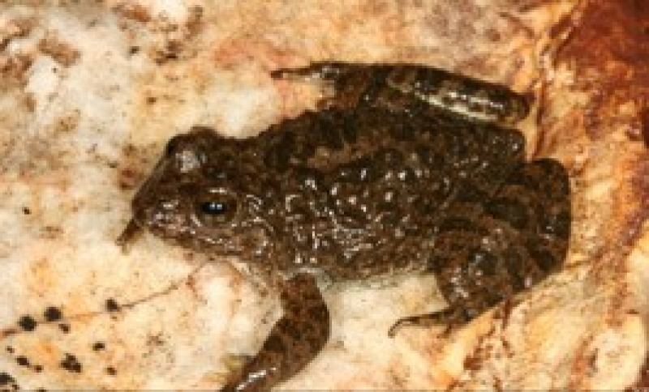

© Louis Du Preez

NT to VU

Increase

Deterioration in habitat quality, especially in Lesotho where active and proposed mines have had an observable increased impact (both directly and indirectly) on this species, with projected increased aridification due to climate change, overgrazing and water quality issues that have intensified since the last assessment, resulting in this species’ conservation status deteriorating.

[*Breviceps macrops*](https://www.inaturalist.org/observations?place_id=6986&preferred_place_id=6986&taxon_id=25004)

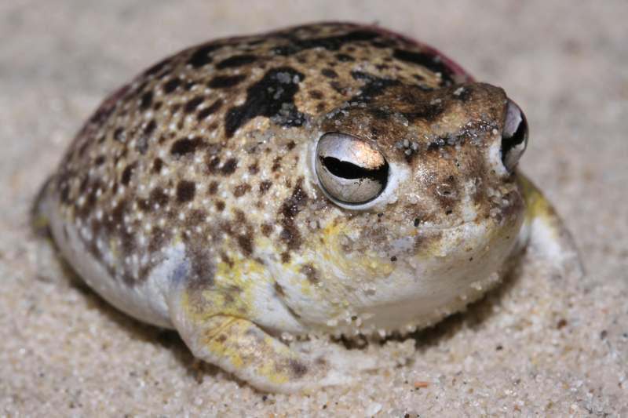

© Nick Telford

NT to VU

Increase

Based on projected increased threats from mining and development. New information on future threatening processes has become available with changes in government policy that will likely lead to increased industrial development in the coastal region of the Northern Cape, South Africa and southwestern Namibia.

[figure not shown]

Figure 4. The distribution of two amphibian species that have experienced a genuine increase in threat status since 2016. They are *Breviceps macrops* (NT to VU), from the West Coast of South Africa, and *Amietia hymenopus* (NT to VU) which occurs on the Drakensberg Escarpment between South Africa and Lesotho,

## Pressures

Globally, habitat loss is the most common threat to amphibians, impacting 93% of threatened species, with agricultural expansion being the leading cause of habitat loss and degradation<sup>5</sup>. For South Africa’s frogs, the main pressures driving declines are impacts from invasive species, affecting 83% of threatened and Near Threatened species (Figure 5). These impacts include replacement of natural habitat due to expansion of woody invasive plants, drying out of wetlands and streams, changes to stream dynamics, including sedimentation, and alteration of natural fire regimes.

**NoteBox 2. Invasive species impacts on range-restricted amphibians**

The Critically Endangered rough moss frog, (*Arthroleptella rugosa*), is restricted to the Klein Swartberg Mountain in the Western Cape. Within less than a decade, large portions of its fynbos seepage habitat have been invaded by cluster pines (*Pinus pinaster*). A study using bioacoustics to estimate frog densities found that numbers at invaded sites were directly affected by *P. pinaster* infestations<sup>6</sup>. At invaded sites, call densities (and hence population numbers) were reduced, while at uninvaded sites call densities were notably higher. These results confirm previous

[figure not shown]

The Critically Endangered rough moss frog, (*Arthroleptella rugosa*). (© Alouis and Keir Lynch Bionerds)

suggestions that invasive pine trees cause population declines in *Arthroleptella rugosa*.

These findings were used as motivation for conservation action and a joint initiative through CapeNature, the Endangered Wildlife Trust, Fynbos Trust, 18 landowners and the Klein Swartberg Conservancy, resulted in adaptive fire management to control pine invasion across the species range. An ecological burn was carried out, which covered approximately 4 000 hectares, and eradicated pines from areas where *Arthroleptella rugosa* occurs. Post-fire monitoring has confirmed increasing numbers of frogs, and a 10-year management plan has been developed with the Conservancy, including ongoing alien plant management. This is a great example of conservation needs being guided by expert knowledge and Red List assessment information, which have also resulted in the designation of this species entire range as an [Alliance for Zero Extinction](https://zeroextinction.org/) site, thus gaining international

[figure not shown]

Pine infestation of fynbos habitat on Klein Swartberg where the Critically Endangered rough moss frog, *Arthroleptella rugosa*, occurs. (© Rob Erasmus, Enviro Wildfire)

attention, strengthening partnerships and work with landowners towards formal habitat protection for this species.

[figure not shown]

Before and after images showing a reduction in pine invasion from July 2021 (left) to April 2022 (right) at the type locality of *Arthroleptella rugosa* through the use of a controlled ecological burn. (© Alouis and Keir Lynch Bionerds)

[figure not shown]

Figure 5. Key pressures affecting threatened and Near Threatened amphbian species. Pressures are categorised using the IUCN Threat Classification Scheme and are ranked from most to least frequent number of impacted species.

**NoteBox 3. The impact of habitat loss and degradation on South Africa’s amphibians**

## Habitat loss to agriculture and plantations

[figure not shown]

Amathole toad (*Vandijkophrynus amatolicus*). (© Alouis and Keir Lynch Bionerds)

through regenerative agriculture approaches and facilitating habitat protection processes through Biodiversity Stewardship may prove beneficial to this toad, while supporting livelihoods within this strategic water source area.

## Habitat loss due to residential and commercial development

Habitat loss to residential and commercial development impacts many of the country’s amphibians. Perhaps none more so than the Western leopard toad (*Scelophrys pantherina*), typically associated with low-lying wetlands and vleis in the Western Cape province. Urban infrastructure such as roads also causes significant individual mortalities of breeding adults every year when toads move from their summer foraging grounds through now developed areas towards suitable breeding

[figure not shown]

Western leopard toad (*Scelophrys pantherina*). (© Luke Verburght)

habitat. Sightings (including roadkill) of this species by the public can be uploaded to iNaturalist, with sightings in the Overberg specifically to this [iNaturalist project](https://www.inaturalist.org/projects/leopard-toads-of-the-overberg).

Contributions of occurrence records of any species are extremely valuable and have made up a significant proportion of data used in the 2025 assessments (See Box 4).

**NoteBox 4. Calling all citizen scientists who might have an interest in these creatures**

To contribute to the future Red List assessments and monitoring of amphibians, join iNaturalist!

[Amphibians of South Africa](https://www.inaturalist.org/observations?place_id=6986&taxon_id=20978&verifiable=any)

New to iNaturalist (or never heard of it) and want to contribute? Watch these [video tutorials](https://inaturalist.freshdesk.com/en/support/solutions/folders/151000547795) to get started and sign up on the [iNaturalist website](https://www.inaturalist.org/observations?place_id=6986&taxon_id=121773) or download the app on your smartphone.  
To see how valuable your nature photographs can be, watch this inspiring [TED talk](https://www.ted.com/talks/148410).

[figure not shown]

## Protection level

The protection level assessment was conducted for 133 of South Africa’s 135 described amphibian species (Figure 6). Two peripheral taxa with less than 5% of their distribution in South Africa were excluded from the analysis. Protection levels were calculated for amphibians by intersecting amphibian occurrence records with the protected area spatial layer, and calculating the area required to protect a target population of 10 000 individuals. Protection levels were also adjusted based on the management effectiveness of protected areas. For further details on the method used to conduct this assessment see here.

[figure not shown]

Figure 6. Protection level for amphibians was assessed for 133 taxa. (A) shows the protection level for all taxa; (B) shows the protection level for South African endemics.

[figure not shown]

The mosaic of wetland habitat at the Nuwejaars Wetlands Special Management Area where the micro frog (*Microbatrachella capensis*) was discovered in 2021. Alien clearing efforts and population density estimates are currently underway using *M. capensis* as a management target. (© Keir Lynch Bionerds)

Nine species have had improvements in their protection level, from Poorly Protected to Moderately Protected (8 species) or Well Protected (1 species). Examples of threatened species that have benefitted from improved protection include the Endangered micro frog (*Microbatrachella capensis*), Pickersgill’s reed frog (*Hyperolius pickersgilli*), and the Cape platanna (*Xenopus gilli*). In the case of *H. pickersgilli*, an additional 16 sites have been confirmed for the species since 2017, with several of these occurring within protected areas<sup>7</sup>.

Habitat protection gains have been a key outcome of the coordination of the [Biodiversity Management Plan](https://www.gov.za/sites/default/files/gcis_document/201706/40883gen423.pdf) for this species, with several sites (totalling 127 hectares) being declared through the Biodiversity Stewardship Programme, as well as improved management and wetland health for these, and existing protected areas<sup>7</sup>. For *M. capensis*, confirmation of the species in the Nuwejaars Wetlands Special Management Area in 2021, which is now being managed with the frog as a management target, has resulted in both an expansion of the species’ range with protected areas as well as improved management effectiveness scores from fair to good. It is important to recognise the contribution that Biodiversity Stewardship and conservation servitudes (or OECMs) makes to the protected area estate through agreements with landowners for targeting unprotected populations of species.

[figure not shown]

## Species recovery

As part of the Red List process for southern Africa, the Amphibian Ark (AArk) joined the expert workshop and worked with coordinators to produce a Conservation Needs Assessment (CNA) for threatened South African amphibian species<sup>8</sup>. This used a process developed by AArk to determine which species have the most urgent conservation needs, based on action plans that combine i*n situ* and *ex situ* actions, as appropriate. Six South African species were identified for *ex situ* conservation actions, including *ex situ* rescue (n = 5) and *ex situ* research (n = 1). Due to their level of threat, the five species recommended for *ex situ* rescue are also recommended for biobanking. Twenty-five species were recommended for *in situ* conservation, and 34 species are recommended for *in situ* research, while 15 species were identified for conservation education programs.

In addition, subsequent work to identify species requiring urgent recovery under [Target 4](https://www.cbd.int/gbf/targets/4) of the Kunming-Montreal Global Biodiversity Framework resulted in 12 species being prioritised for Green Status assessments and 9 of these as Target 4 species. This includes threatened endemic species and those of regional importance that might go extinct even if their habitat is protected. This highlights the limited targeted management of amphibians within protected areas and the need for research on how they respond to management interventions.

South Africa has a relatively proactive community working on amphibian conservation and research, with NGOs, provincial authorities and various universities contributing to building conservation evidence for assessing the effectiveness of conservation interventions and growing the body of knowledge on amphibian taxonomy, behaviour and ecology (Table 3). These activities were partially guided by the conservation and research strategy compiled following the 2010 Red List assessments<sup>9</sup>, demonstrating the value of these processes, with plans in place to update this strategy following the most recent assessments (2025). While progress has been made, amphibian conservation capacity remains overlooked and underfunded compared to other taxa<sup>10</sup>, and this is particularly pertinent in the African context, with limited resources in general, and the constant need to balance development needs with conservation efforts.

Table 3. List of some of the active recovery projects focused on amphibians across South Africa led by a range of different organisations.

| Focal species | Organisation | Province(s) | Conservation Action | Get involved |
| --- | --- | --- | --- | --- |
| Amathole Toad | EWT | EC | Habitat protection and management | https://ewt.org/ |
| Bilbo's Rain Frog | Anura Africa/NWU | KZN | Research on distribution, genetics and stakeholder engagement | https://www.anuraafrica.org/ |
| Kloof Frog | Anura Africa/NWU/Ezemvelo KZN Wildlife/EWT | KZN | Long-term monitoring; Research on ecology; water quality indicator | https://www.anuraafrica.org/ |
| Long-toed Tree Frog | Anura Africa/Ezemvelo KZN Wildlife/NWU | KZN | Building conservation evidence and population data using monitoring to inform habitat protection and management | https://www.anuraafrica.org/ |
| Micro Frog | Anura Africa/Grootbos Foundation/EWT | WC | Using bioacoustics to inform conservation management | https://www.anuraafrica.org/ |
| Moonlight Mountain Toadlet | EWT | WC | Habitat protection and management | https://ewt.org/ |
| Moss frogs (multiple species) | CapeNature | WC | Long-term monitoring |  |
| Pickersgill's Reed Frog | Ezemvelo KZN Wildlife/Anura Africa/EWT | KZN | Implementation of actions through a coordinated Biodiversity Management Plan | https://www.anuraafrica.org/ |
| Rose's Mountain Toadlet | EWT/UCT/SANBI | WC | Improved management through stakeholder collaboration | https://ewt.org/ |
| Rough Moss Frog | EWT/CapeNature/Fynbos Trust | WC | Habitat protection and management | https://ewt.org/ |
| Table Mountain Ghost Frog | EWT/SANBI | WC | Improved management through stakeholder collaboration | https://ewt.org/ |
| Western Leopard Toad | SANBI/City of CT/EWT/Volunteer organisations/NatureConnect | WC | Genetic studies, road ecology, threat mitigation | https://natureconnect.earth/nature-care-fund/species-conservation/ |

**NoteBox 5. Pickersgill’s reed frog: conservation action at work**

[figure not shown]

Release site for captive-bred Pickersgill’s reed frog in 2018 when 400 captive-bred individuals were released back into the wild through collaboration between Ezemvelo KZN Wildlife, Joburg Zoo and the Endangered Wildlife Trust. (© Joburg Zoo)

[figure not shown]

Partnering for Pickersgill’s reed frog (*Hyperolius pickersgilli*) - a sign put up at various *H. pickersgilli* sites explaining the Biodiversity Management Plan.

## Knowledge gaps

While amphibians globally remain the most threatened (41%) vertebrates on Earth, basic data on species distribution, population numbers, and ecology remain poor. This is likely partly a result of limited funding, with amphibians receiving the least conservation funding of all major groups globally. Less than 2.8% of funding support is directed to amphibians, and this has declined from 4% in the 1990s<sup>10</sup>. Projects on amphibians are also often focussed on multiple species, limiting per species investment. This differs from projects focussed on other taxa that often receive disproportional support, including for non-threatened species (e.g., large mammals). This lack of funding is likely the root cause of several knowledge gaps discussed below and is also linked to inadequate capacity in amphibian research and conservation. These gaps are even more acute outside of South Africa in other parts of the continent.

Similarly, despite major efforts in recent decades to improve knowledge on amphibian declines, there remains a disconnect between research and its translation into conservation actions. Research priorities identified at the global scale include a better understanding of the effects of climate change, community-level drivers of declines, methodological improvements for research and monitoring, genomics, and effects of land-use change. Improved inclusion of under-represented amphibian species in conservation projects was also highlighted<sup>4</sup>. In South Africa, growing amphibian conservation and research capacity in a more representative way is critical to addressing capacity gaps and providing skills transfer to young researchers to grow core conservation expertise.

Amphibian Red List assessments primarily apply criterion B (geographic range information). Research projects that generate population data, both over time and in response to threats and management interventions, will be useful to strengthen amphibian Red List assessments, and in turn to provide baseline data for adaptive conservation strategies. Using the outputs from Red List assessments, including recommended conservation and research actions, is crucial for prioritising and guiding future conservation strategies, and such strategies have been found to be effective in improving taxonomy, ecological studies, monitoring, research outputs, and capacity building<sup>11</sup>.

## Approach

### Threat status assessments

All previously assessed South African amphibians were reassessed as part of the Southern African Amphibian Red List Project (SAARLP) that commenced in 2023, as part the third global amphibian assessment process, supported by the IUCN Amphibian Specialist Group and Amphibian Red List Authority. A total of 135 species were assessed for publication on the IUCN Red List in 2025 and 2026, including 11 newly described species<sup>12</sup>. Over 150 000 records were collated for the assessments, including from various institutions and verified citizen science data. Twenty experts representing thirteen organisations contributed to the assessment process.

See details about how the IUCN Red List assessments are conducted here.

### Protection level assessments

The species protection level assessment measures the contribution of South Africa’s protected area network to species persistence. It evaluates progress towards the protection of a population target for each species, set at the level of protection needed to support long-term population survival.

Amphibian protection level was assessed for NBA 2018 and was repeated in 2025 using updated species occurrence data based on the 2025 Amphibian Red List Reassessment. A spatial layer of protected areas for 2018 and 2025 representing protected areas that were declared at that time were used for the two time periods. A technical report outlining the full methodology and limitations will be available in February 2026.

See details about how the protection level indicator was conducted here.

## Acknowledgements

**Coordinated by:**

- [Anura Africa](https://www.anuraafrica.org/)
- [Endangered Wildlife Trust](https://ewt.org/)
- [Whitley Fund for Nature](https://whitleyaward.org/)

**Sponsored by:**

- [Anglo American](https://www.angloamerican.com/)
- [Re:wild](https://www.rewild.org/)
- [Synchronicity Earth](https://www.synchronicityearth.org/)
- [Rainforest Trust](https://www.synchronicityearth.org/)

**Supported by:**

- [IUCN SSC Amphibian Specialist Group](https://www.iucn-amphibians.org/)
- [South African National Biodiversity Institute](https://www.sanbi.org/)

### Contributors

Table 4. List of contributors and reviewers to the assessment of South Africa amphibians and other activities related to amphibian conservation.

| Contributor | Affiliation |
| --- | --- |
| Adriaan Jordaan | University of the Western Cape, Iziko South African Museum |
| Adrian John Armstrong | Ezemvelo KZN Wildlife |
| Andrew Turner | Cape Nature |
| Anisha Dayaram | South African National Biodiversity Institute |
| Carol Poole | South African National Biodiversity Institute |
| Che Weldon | North-West University |
| Darren Pietersen | Endangered Wildlife Trust |
| Fortunate Mafeta Phaka | North-West University |
| Francois Stephanus Becker | Gobabeb Research and Training Centre, National Museum of Namibia, University of Cape Town, University of the Witwatersrand |
| James Harvey | Harvey Ecological |
| John Measey | Centre for Invasion Biology, Stellenbosch University |
| Keir Lynch | Anura Africa;Bionerds |
| Krystal A. Tolley | South African National Biodiversity Institute |
| Louis Heyns Du Preez | North-West University |
| Luke Verburgt | Enviro Insight |
| Mohlamatsane Mokhatla | University of Pretoria |
| Nieto Lawrence, J. A. | Anura Africa; University of Johannesburg |
| Ninda Baptista | Universidade do Porto, Portugal |
| Oliver Angus | Endangered Wildlife Trust (at the time of assessments) |
| Werner Conradie | Port Elizabeth Museum |

## Technical documentation

### Data sources

1. DFFE. 2024. South African Protected Areas Database (SAPAD), Version 2024_Q3 (modified by SANBI). DFFE, Pretoria. Available at: https://www.dffe.gov.za/egis. Accessed: 25 August 2024.
2. Van der Colff, Dewidine (2026). South African National Biodiversity Assessment Species Summary Status Checklist 2025. figshare. Dataset. https://doi.org/10.6084/m9.figshare.31650961.v3

## Recommended citation

Tarrant, J., Weeber, J., Raimondo, D.C., Monyeki, M.S., Van Der Colff, D., & Hendricks, S.E. 2025. Amphibians. National Biodiversity Assessment 2025. South African National Biodiversity Institute. http://nba.sanbi.org.za/.

## References

1. Borgelt, J. et al. 2022. More than half of data deficient species predicted to be threatened by extinction. *Commun Biol* 5: 679. https://doi.org/10.1038/s42003-022-03638-9

2. Butchart, S.H.M. et al. 2004. Measuring global trends in the status of biodiversity: Red List indices for birds. *PLoS Biology* 2: https://doi.org/10.1371/journal.pbio.0020383

3. Du Preez, L.H. et al. 2025. A new rain frog (anura: Brevicipitidae; breviceps) from the KwaZulu-natal midlands, south africa. *African Journal of Herpetology*. https://doi.org/10.1080/21564574.2025.2478896

4. Campbell Grant, A., E. H. 2023. Priority research needs to inform amphibian conservation in the anthropocene. *Conservation Science and Practice* e12988: https://doi.org/10.1111/csp2.12988

5. Rewild. 2023. *Synchronicity earth, IUCN SSC amphibian specialist group*. Re:wild, Texas, USA.

6. Angus, O. et al. 2023. In a rough spot: Declines in arthroleptella rugosa calling densities are explained by invasive pine trees. *Austral* Ecology48(3: 498–512. https://doi.org/10.1111/aec.13273

7. Armstrong, A.J. et al. 2025. Collaborating for conservation: The first five years of implementation of the biodiversity management plan for pickersgill’s reed frog, hyperolius pickersgilli’. *African Biodiversity & Conservation* 55: 7. https://doi.org/10.38201/abc.v55.7

8. Brunner, R. et al. (eds). 2025. *Conservation needs assessment workshop report for threatened south african amphibian species 2024*. Amphibian Ark.

9. Measey, G.J. (eds). 2011. *Ensuring a future for south africa’s frogs: A strategy for conservation research, SANBI biodiversity series 19*. South African National Biodiversity Institute, Pretoria.

10. Guénard, B. 2025. Limited and biased global conservation funding means most threatened species remain unsupported. *Proc. Natl Acad.Sci* 122: 2412479122.

11. Measey, J. et al. 2019. Has strategic planning made a difference to amphibian conservation research in south africa?’ *Bothalia* 49: 2428. https://doi.org/10.4102/abc.v49i1.2428

12. Frost, D.R. 2025. *Amphibian species of the world: An online reference. Version 6.2 (date of access). Electronic database accessible at https://amphibiansoftheworld.amnh.org/index.php*. American Museum of Natural History, New York, USA. https://doi.org/10.5531/db.vz.0001